# The Index of Naural Resource Value: A Tool for Assessing the Integrity of Natural Areas in Cleveland Metroparks

Author: John Reinier

Last Updated: 2025-06-09

# Study Area

[figure not shown]

# Methods

# Metric Descriptions

## Wetland Quantity

This metric assigns points based on the percentage of the catchment mapped as wetland. The score breakpoints are:

50% or greater - 10 points  
25% to 50% - 7 points  
10% to 25% - 5 points  
5% to 10% - 3 points  
1% to 5% - 1 point

## Wetland Quality

Points are assigned according to the weighted average ORAM score/category within a catchment. Example: Wetland A is 3 acres with an ORAM score of 50, Wetland B is 2 acres with a score of 75 and Wetland C is 2 acres with a score of 60. Next, multiply each wetland acreage by its ORAM score and add the products together: (50x3) + (75x2) + (60x2) = 420. Finally, divided by the total acreage to get the weighted average score: 420/7 = 60. The weighted average ORAM category is then determined using Ohio EPA’s breakpoints (Mack 2000).

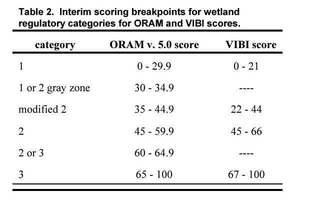

ORAM Category 3 - 10 points  
ORAM Category 2b - 7 points  
ORAM Category 2a - 3 points  
ORAM Category 1 - 1 point

## Stream Quality

Point are assigned according to the weighted average stream biological assessment score/category within a catchment. To get the weighted average score, points representing assessment sites were joined to the appropriate stream segment and “walked” updstream until the next assessment point is encountered. This allows assessment data to get applied to a stretch of stream rather than just a single point. The length is then used as a weigting factor for the weighted average calculation.

**Network Walking**

WITH walked AS (  
WITH RECURSIVE walk_network(wkb_geometry,  
reference_stream_id,  
ogc_fid,  
“year”,  
“type”,  
score,  
narr,  
x1,  
y1,  
x2,  
y2) AS (  
SELECT a.wkb_geometry,  
a.reference_stream_id,  
a.ogc_fid,  
b.”year”,  
b.”type”,  
b.score,  
b.narr,  
a.x1,  
a.y1,  
a.x2,  
a.y2  
FROM nr_sensitivity.all_stream_data_merged_to_segment a  
LEFT JOIN nr_sensitivity.bio_narrative_to_streams b ON a.ogc_fid = b.ogc_fid  
WHERE a.reference_stream_id IS NOT NULL  
UNION ALL  
SELECT n.wkb_geometry,  
w.reference_stream_id,  
n.ogc_fid,  
w.”year”,  
w.”type”,  
w.score,  
w.narr,  
n.x1,  
n.y1,  
n.x2,  
n.y2  
FROM nr_sensitivity.all_stream_data_merged_to_segment n,  
walk_network w  
WHERE n.x2 = w.x1 AND n.y2 = w.y1 AND n.hhei_score IS NULL  
)  
SELECT walk_network.wkb_geometry,  
walk_network.ogc_fid,  
walk_network.reference_stream_id,  
walk_network.”type”,  
walk_network.score,  
walk_network.”year”,  
walk_network.narr,  
walk_network.x1,  
walk_network.x2,  
walk_network.y1,  
walk_network.y2  
FROM walk_network  
ORDER BY walk_network.reference_stream_id, walk_network.ogc_fid  
)  
SELECT a.ogc_fid,  
a.wkb_geometry,  
a.type_code,  
a.network,  
a.x1,  
a.y1,  
a.x2,  
a.y2,  
a.tostream,  
b.reference_stream_id,  
b.score,  
CASE  
WHEN b.”type” = ‘cm hmfei’ THEN b.”year”  
ELSE c.”year”  
END  
AS applied_bio_assess_year,  
CASE  
WHEN b.”type” = ‘cm hmfei’ THEN b.”type”  
ELSE c.”type”  
END  
AS applied_bio_assess_type,  
CASE  
WHEN b.”type” = ‘cm hmfei’ THEN b.score  
ELSE c.score  
END  
AS applied_bio_assess_score,  
CASE  
WHEN b.”type” = ‘cm hmfei’ THEN b.narr  
ELSE c.narr  
END  
AS applied_bio_assess_narr  
FROM nr_sensitivity.all_stream_data_merged_to_segment a  
LEFT JOIN walked b ON a.ogc_fid = b.ogc_fid  
LEFT JOIN nr_sensitivity.bio_narrative_to_streams c ON a.ogc_fid = c.ogc_fid  
;

[figure not shown]

Stream quality metric points are assigned as follows:

Biology Narrative is “Exceptional” or “Very Good” - 10 points  
Biology Narrative is “Good” - 7 points  
Biology Narrative is “Marginally Good” - 5 points  
Biology Narrative is “Fair” - 3 points  
Biology Narrative is “Poor” or “Very Poor” - 1 point

## Rare Features

Points for this metric are assigned based on the occurrence of rare taxa within a catchment. Each taxon is only counted once per catchment it occurs in even though there may be multiple individual records for it. Conservation status assignment generally follows the Natureserve methodology (Natureserve citation).

Taxa of Global Conservation Concern (G1, G2, G3) - 10 points  
Ohio endangered taxa - 7 points  
Ohio threatened taxa - 5 points  
Ohio potentially threatened taxa - 3 points  
Cleveland Metroparks rare taxa (P1, P2) - 1 point

## Results

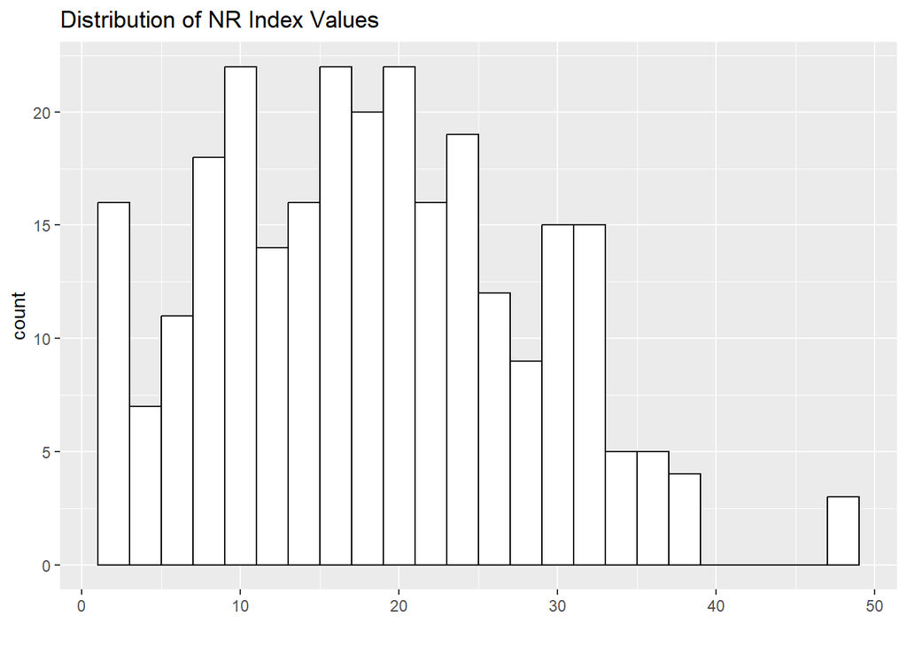

```r
ggplot(nr.index[nr.index.sub2,], aes(x = nr_value_index)) +
  geom_histogram (colour = "black", fill = "white", binwidth = 2) +
  ggtitle("Distribution of NR Index Values") +
  xlab("")
```

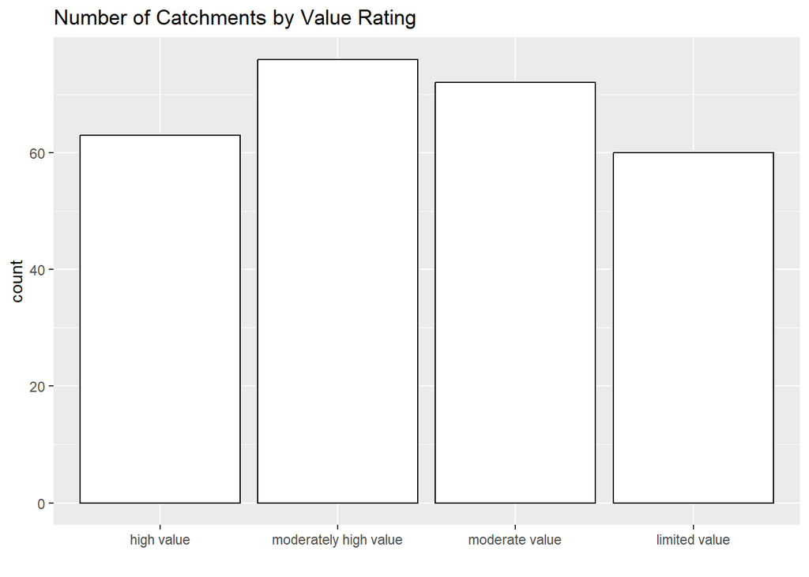

```r
ggplot(nr.index[nr.index.sub2,], aes(nr_value_index_narrative)) +
  geom_bar(colour = "black", fill = "white", stat = "count") +
  scale_x_discrete(limits=c("high value", "moderately high value", "moderate value", "limited value")) +
  ggtitle("Number of Catchments by Value Rating") +
  xlab("")
```

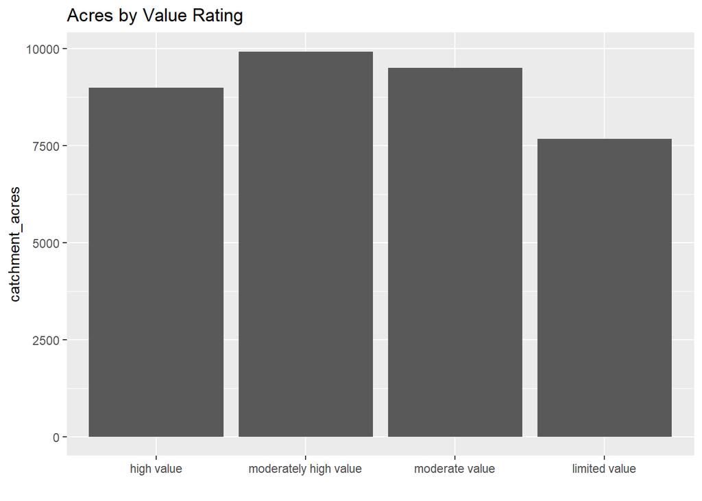

```r
ggplot(nr.index, aes(x = nr_value_index_narrative, y = catchment_acres)) +
  geom_bar(stat = "identity") +
  scale_x_discrete(limits=c("high value", "moderately high value", "moderate value", "limited value")) +
  ggtitle("Acres by Value Rating") +
  xlab("")
```

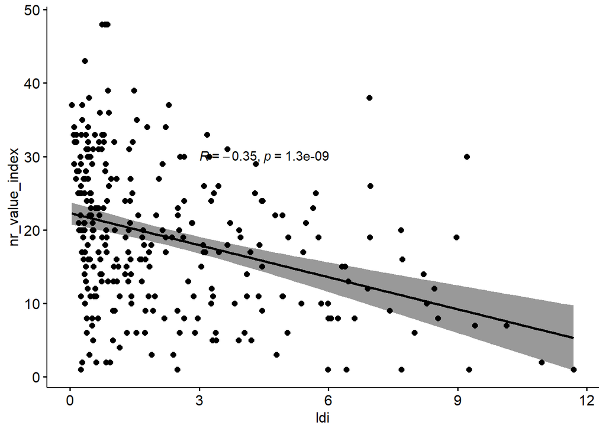

```r
index_ldi_plot <- ggscatter(nr.index, x = "ldi", y = "nr_value_index",
                add = "reg.line",
                conf.int = TRUE)+
  stat_cor(method = "pearson", label.x = 3, label.y = 30)
index_ldi_plot
```

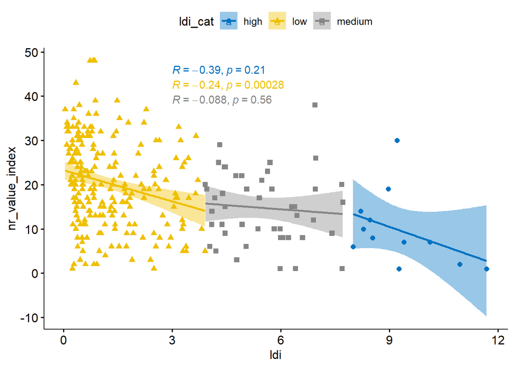

```r
index_ldi_plot2 <- ggscatter(nr.index, x = "ldi", y = "nr_value_index",
                add = "reg.line",               # Add regression line
                conf.int = TRUE,                # Add confidence interval
                color = "ldi_cat", palette = "jco", # Color by groups
                shape = "ldi_cat")+
  stat_cor(aes(color = ldi_cat), label.x = 3)
index_ldi_plot2
```

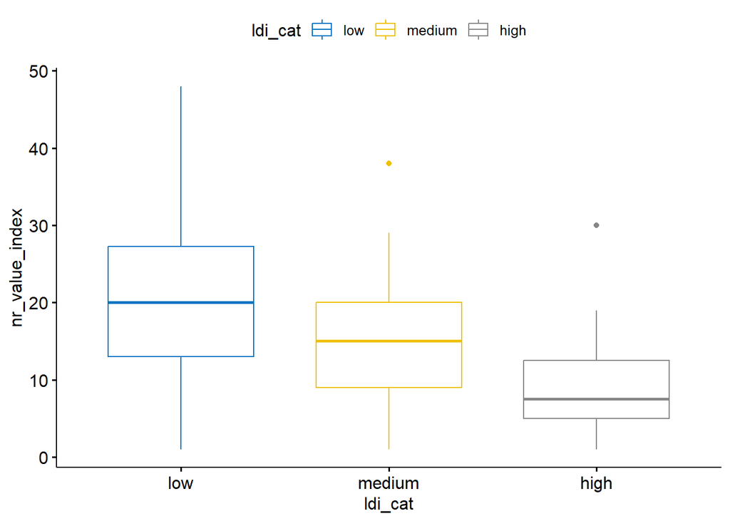

```r
index_score_boxplot <- ggboxplot(nr.index, x = "ldi_cat", y = "nr_value_index",
                color = "ldi_cat", palette = "jco") # Color by groups
index_score_boxplot
```

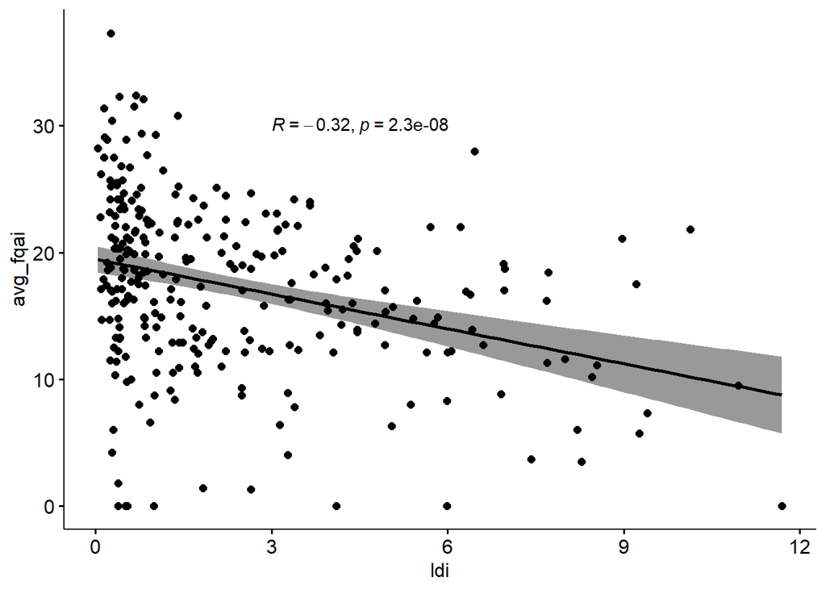

```r
fqai_ldi_plot <- ggscatter(nr.index, x = "ldi", y = "avg_fqai",
                add = "reg.line",
                conf.int = TRUE)+
  stat_cor(method = "pearson", label.x = 3, label.y = 30)
fqai_ldi_plot
```

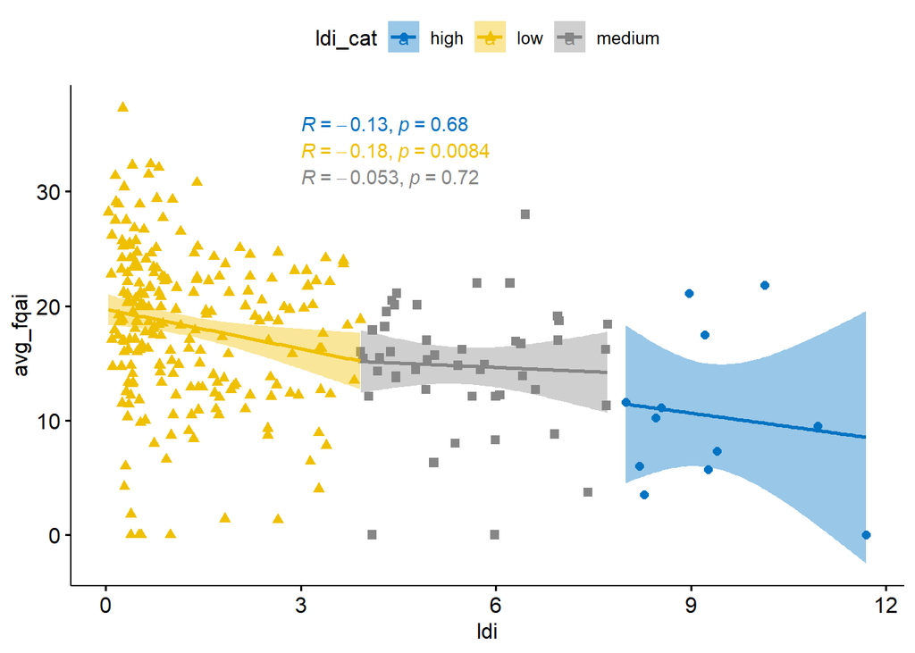

```r
fqai_ldi_plot2 <- ggscatter(nr.index, x = "ldi", y = "avg_fqai",
                add = "reg.line",
                conf.int = TRUE,
                color = "ldi_cat", palette = "jco",
                shape = "ldi_cat")+
  stat_cor(aes(color = ldi_cat), label.x = 3)
fqai_ldi_plot2
```

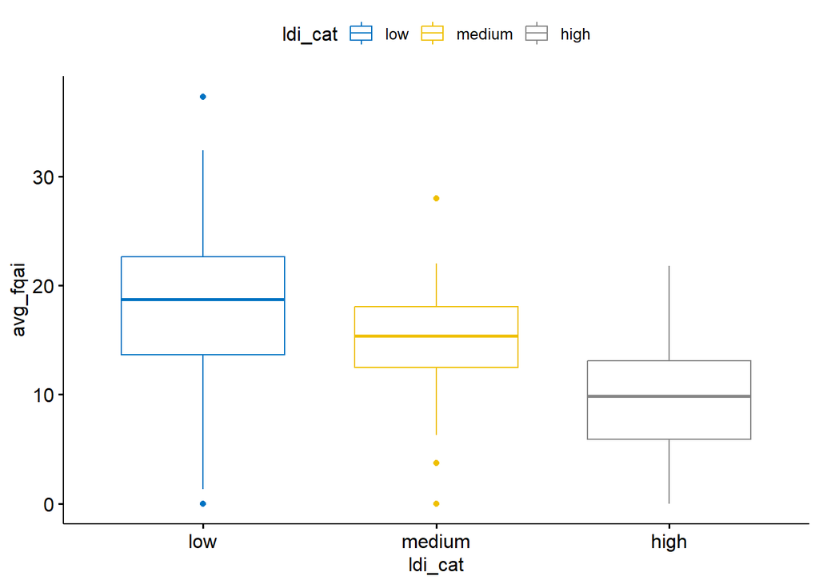

```r
fqai_ldi_boxplot <- ggboxplot(nr.index, x = "ldi_cat", y = "avg_fqai",
                color = "ldi_cat", palette = "jco") # Color by groups
fqai_ldi_boxplot
```

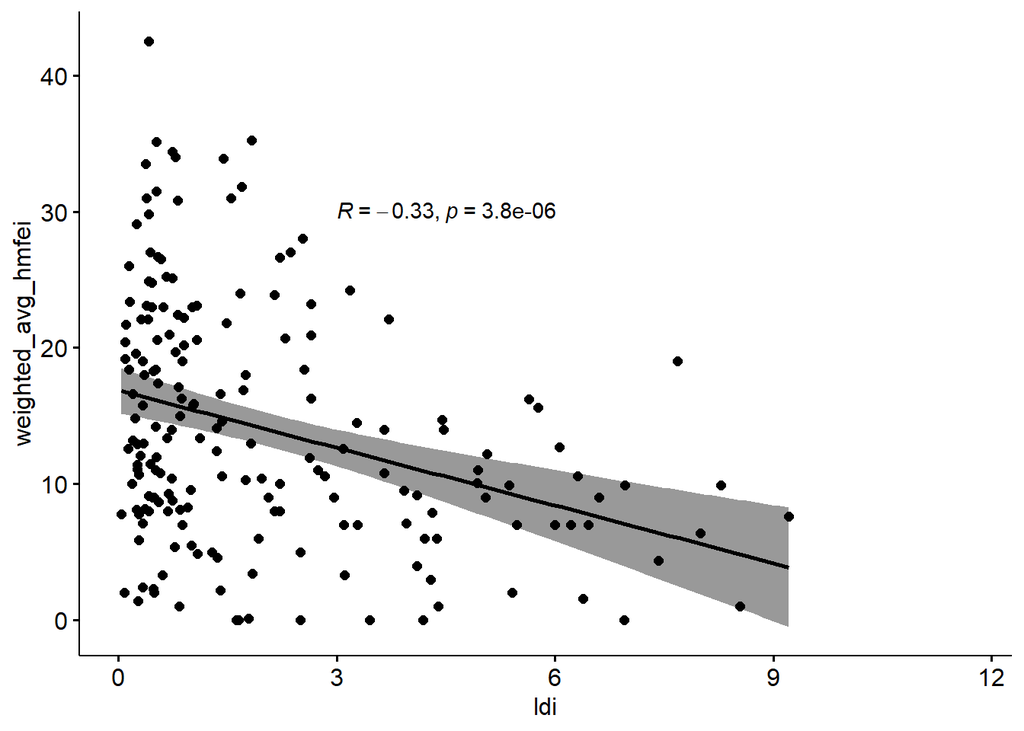

```r
hmfei_ldi_plot <- ggscatter(nr.index, x = "ldi", y = "weighted_avg_hmfei",
                add = "reg.line",
                conf.int = TRUE)+
  stat_cor(method = "pearson", label.x = 3, label.y = 30)
hmfei_ldi_plot
```

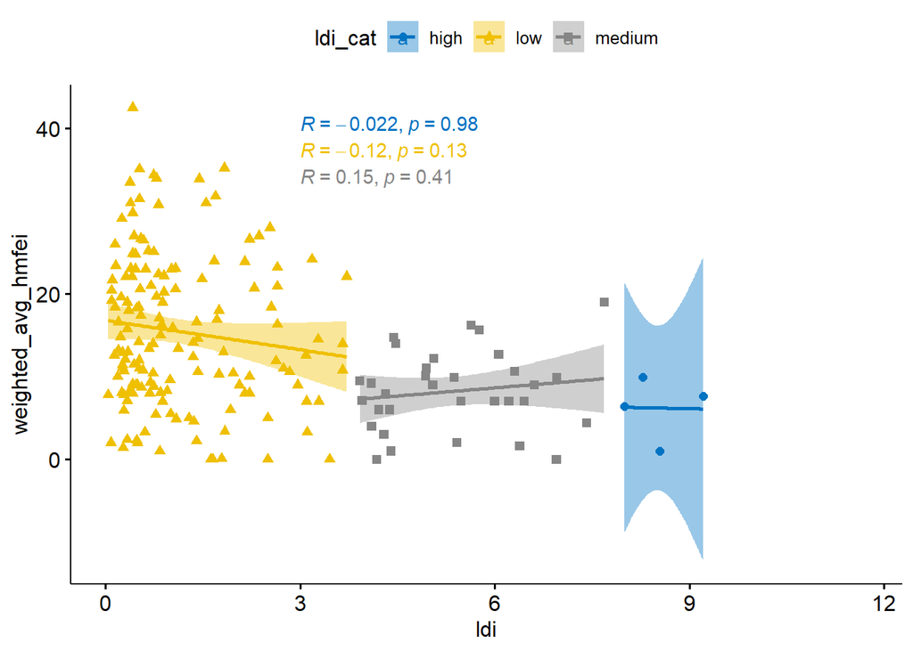

```r
hmfei_ldi_plot2 <- ggscatter(nr.index, x = "ldi", y = "weighted_avg_hmfei",
                add = "reg.line",               # Add regression line
                conf.int = TRUE,                # Add confidence interval
                color = "ldi_cat", palette = "jco", # Color by groups
                shape = "ldi_cat")+
  stat_cor(aes(color = ldi_cat), label.x = 3)
hmfei_ldi_plot2
```

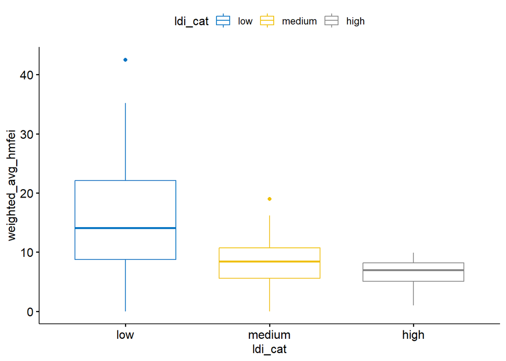

```r
hmfei_score_boxplot <- ggboxplot(nr.index, x = "ldi_cat", y = "weighted_avg_hmfei",
                color = "ldi_cat", palette = "jco") # Color by groups
hmfei_score_boxplot
```

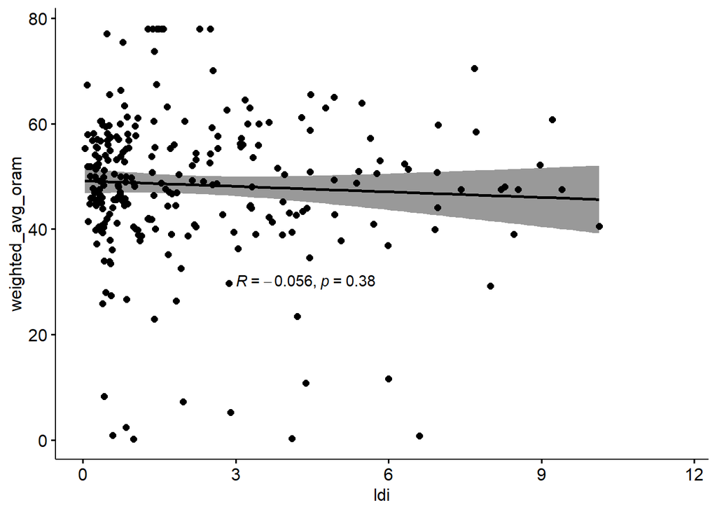

```r
oram_ldi_plot <- ggscatter(nr.index, x = "ldi", y = "weighted_avg_oram",
                add = "reg.line",
                conf.int = TRUE)+
  stat_cor(method = "pearson", label.x = 3, label.y = 30)
oram_ldi_plot
```

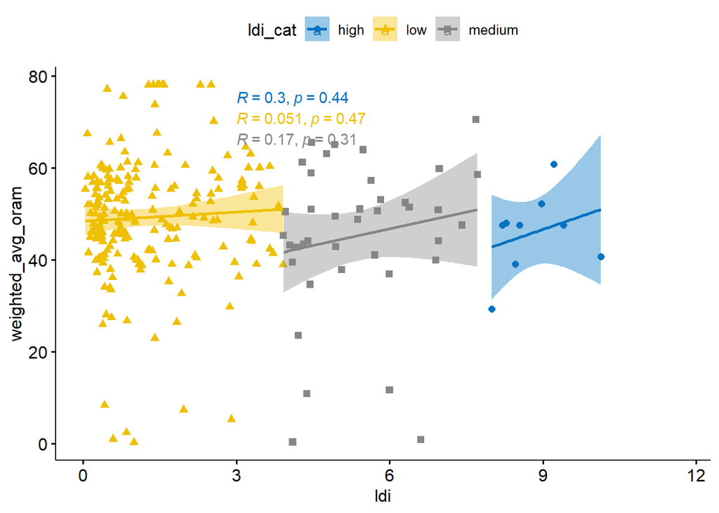

```r
oram_ldi_plot2 <- ggscatter(nr.index, x = "ldi", y = "weighted_avg_oram",
                add = "reg.line",               # Add regression line
                conf.int = TRUE,                # Add confidence interval
                color = "ldi_cat", palette = "jco", # Color by groups
                shape = "ldi_cat")+
  stat_cor(aes(color = ldi_cat), label.x = 3)
oram_ldi_plot2
```

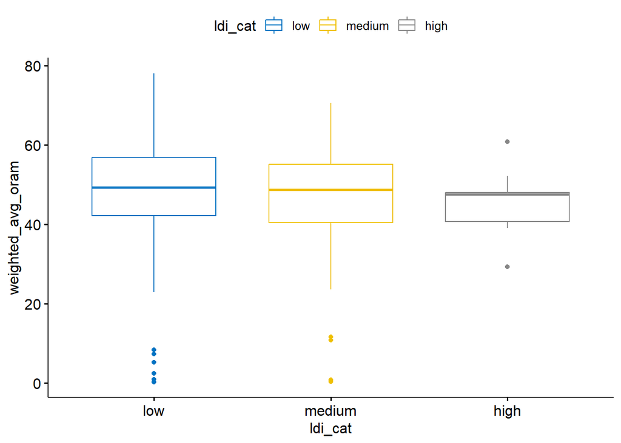

```r
oram_score_boxplot <- ggboxplot(nr.index, x = "ldi_cat", y = "weighted_avg_oram",
                color = "ldi_cat", palette = "jco") # Color by groups
oram_score_boxplot
```

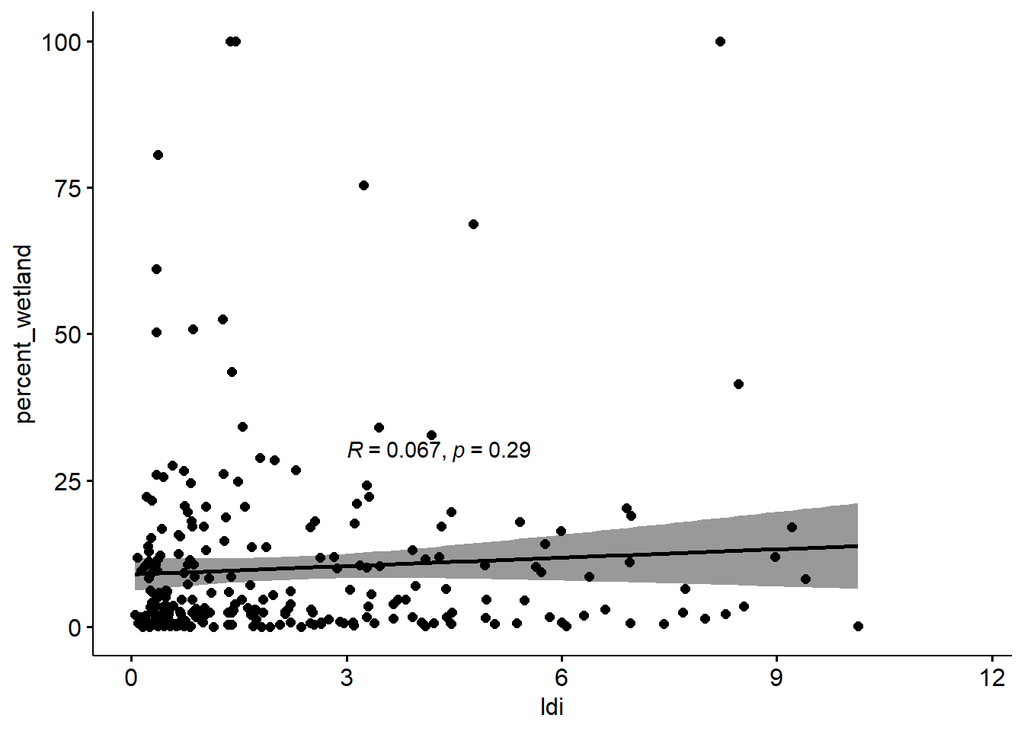

```r
perc_wet_ldi_plot <- ggscatter(nr.index, x = "ldi", y = "percent_wetland",
                add = "reg.line",
                conf.int = TRUE)+
  stat_cor(method = "pearson", label.x = 3, label.y = 30)
perc_wet_ldi_plot
```

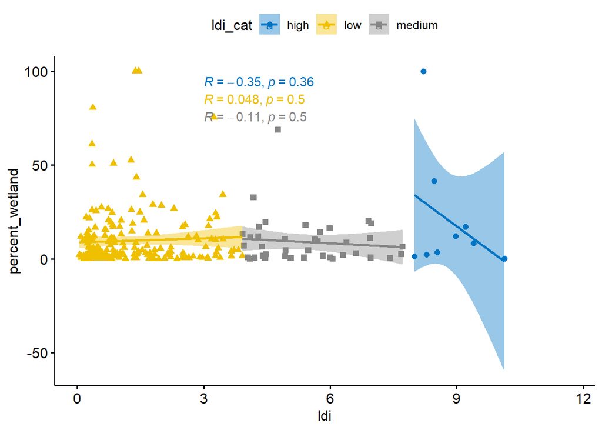

```r
perc_wet_ldi_plot2 <- ggscatter(nr.index, x = "ldi", y = "percent_wetland",
                add = "reg.line",               # Add regression line
                conf.int = TRUE,                # Add confidence interval
                color = "ldi_cat", palette = "jco", # Color by groups
                shape = "ldi_cat")+
  stat_cor(aes(color = ldi_cat), label.x = 3)
perc_wet_ldi_plot2
```

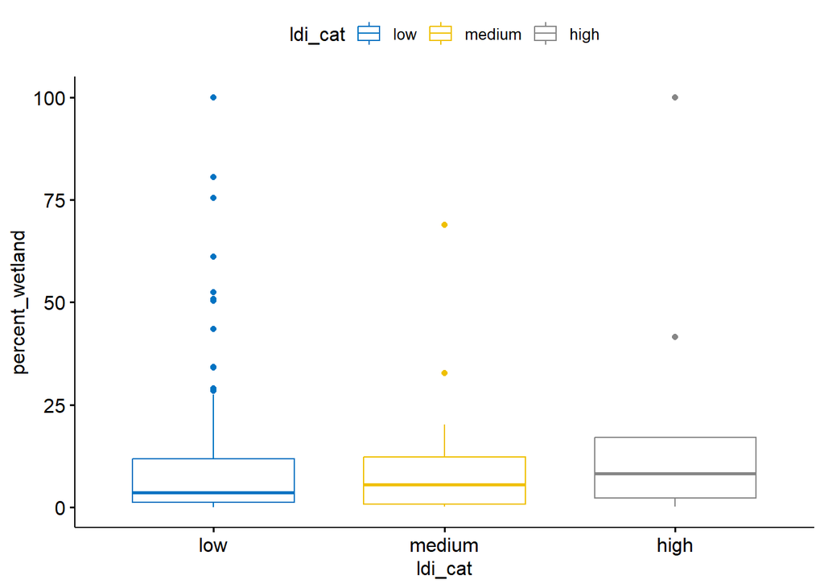

```r
perc_wet_boxplot <- ggboxplot(nr.index, x = "ldi_cat", y = "percent_wetland",
                color = "ldi_cat", palette = "jco") # Color by groups
perc_wet_boxplot
```

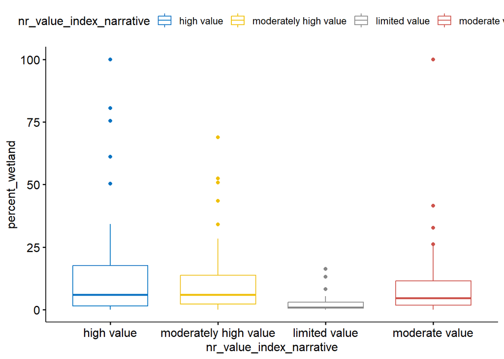

```r
perc_wet_by_index_cat_boxplot <- ggboxplot(nr.index, x = "nr_value_index_narrative", y = "percent_wetland",
                color = "nr_value_index_narrative", palette = "jco")
perc_wet_by_index_cat_boxplot
```

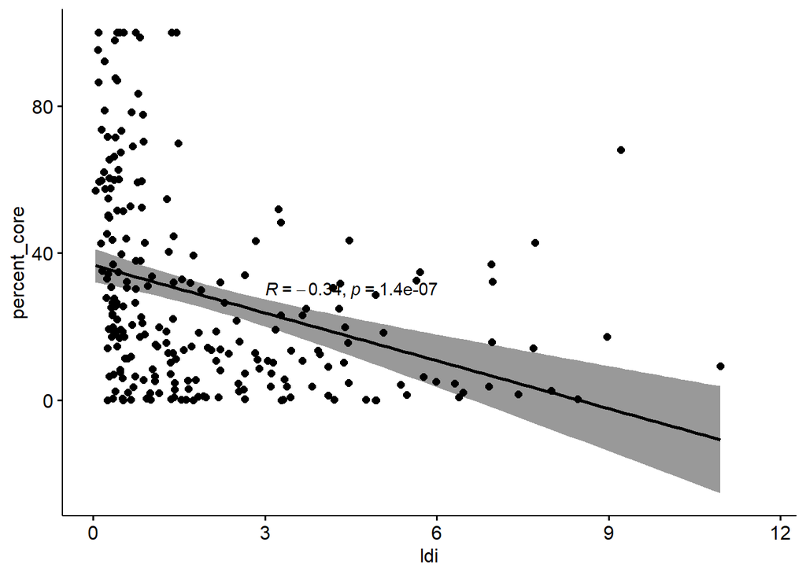

```r
perc_core_ldi_plot <- ggscatter(nr.index, x = "ldi", y = "percent_core",
                add = "reg.line",
                conf.int = TRUE)+
  stat_cor(method = "pearson", label.x = 3, label.y = 30)
perc_core_ldi_plot
```

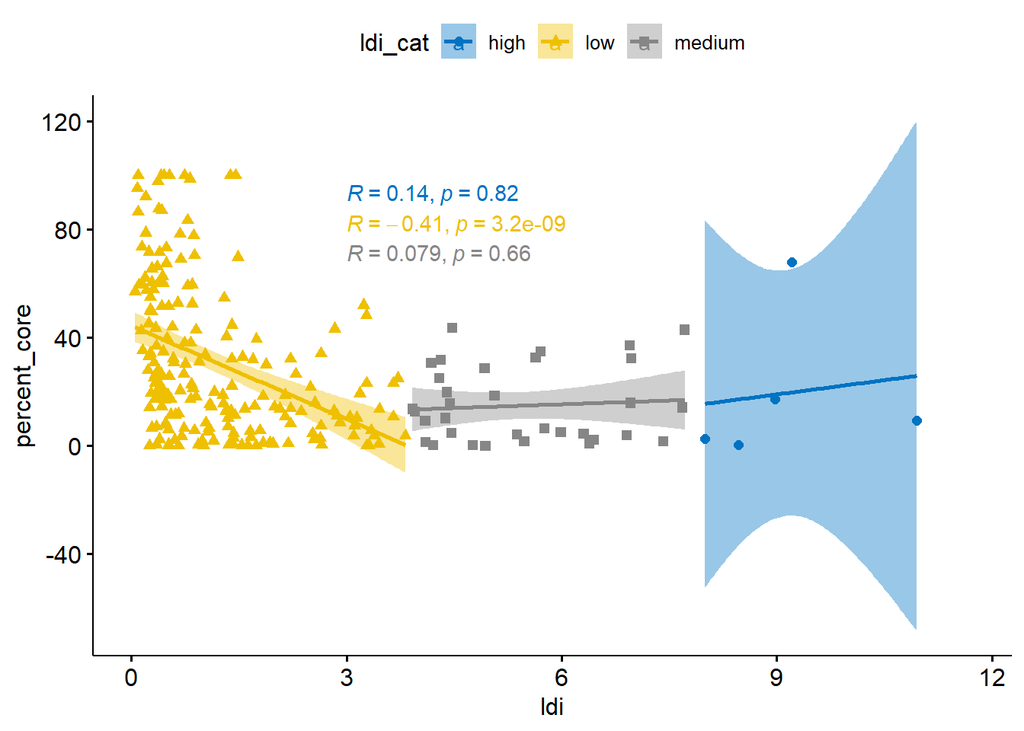

```r
perc_core_ldi_plot2 <- ggscatter(nr.index, x = "ldi", y = "percent_core",
                add = "reg.line",               # Add regression line
                conf.int = TRUE,                # Add confidence interval
                color = "ldi_cat", palette = "jco", # Color by groups
                shape = "ldi_cat")+
  stat_cor(aes(color = ldi_cat), label.x = 3)
perc_core_ldi_plot2
```

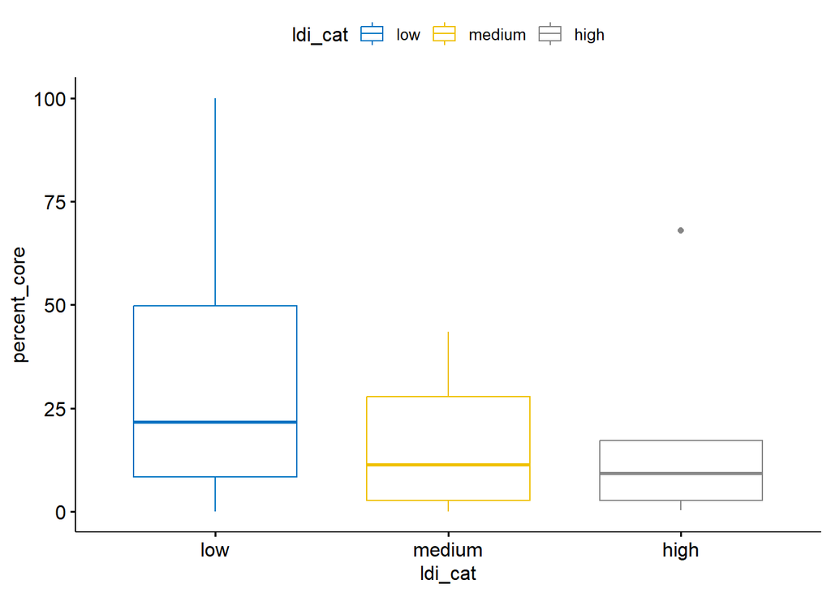

```r
perc_core_boxplot <- ggboxplot(nr.index, x = "ldi_cat", y = "percent_core",
                color = "ldi_cat", palette = "jco") # Color by groups
perc_core_boxplot
```

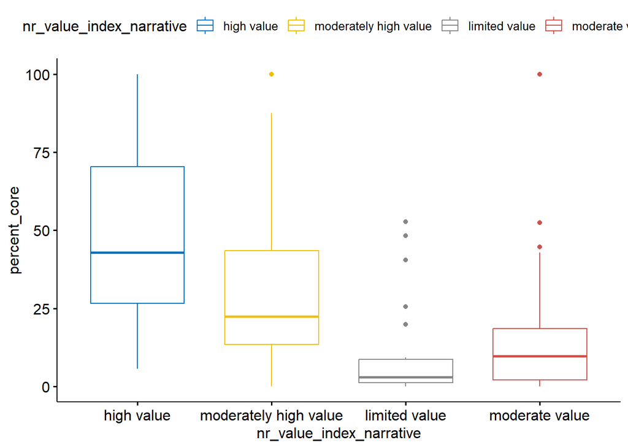

```r
perc_core_by_index_cat_boxplot <- ggboxplot(nr.index, x = "nr_value_index_narrative", y = "percent_core",
                color = "nr_value_index_narrative", palette = "jco")
perc_core_by_index_cat_boxplot
```

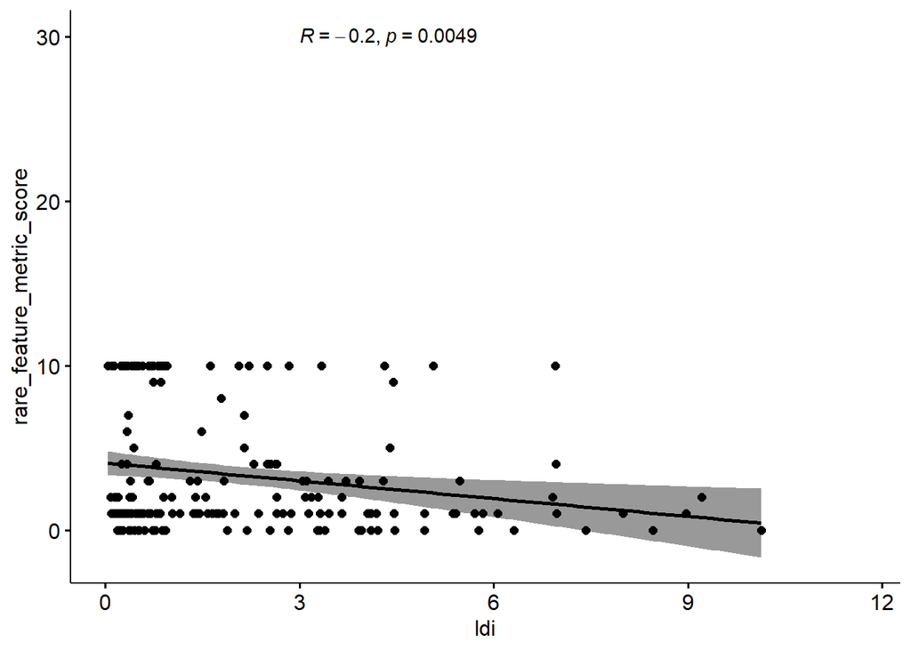

```r
rare_spp_ldi_plot <- ggscatter(nr.index, x = "ldi", y = "rare_feature_metric_score",
                add = "reg.line",
                conf.int = TRUE)+
  stat_cor(method = "pearson", label.x = 3, label.y = 30)
rare_spp_ldi_plot
```

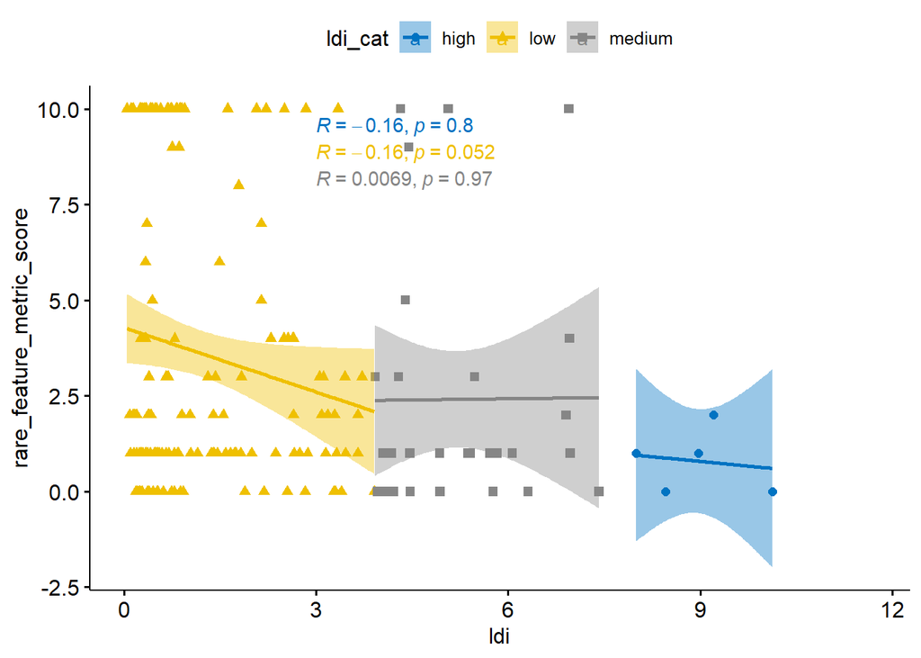

```r
rare_spp_ldi_plot2 <- ggscatter(nr.index, x = "ldi", y = "rare_feature_metric_score",
                add = "reg.line",               # Add regression line
                conf.int = TRUE,                # Add confidence interval
                color = "ldi_cat", palette = "jco", # Color by groups
                shape = "ldi_cat")+
  stat_cor(aes(color = ldi_cat), label.x = 3)
rare_spp_ldi_plot2
```

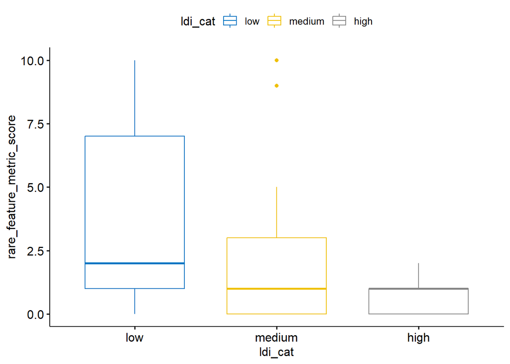

```r
rare_features_score_boxplot <- ggboxplot(nr.index, x = "ldi_cat", y = "rare_feature_metric_score",
                color = "ldi_cat", palette = "jco") # Color by groups
rare_features_score_boxplot
```